# Titanic Analysis

#### This html page, produced by creating an R markdown document, and using KnitR to knit the file into html. The purpose of this html file, is to show our analysis of the Titanic data in the oracle database, as well as show the steps required to reproduce our findings, given the same data. The data for titanic included, the number of passengers, names, how many survived, sex, age, and how much they had paid for their fare. Given these variables, we were able to query the data base in a few different ways, to gather results, and visualize them using ggplot.

##### Rprofile.R:

An Rprofile.R document was created to include all of the packages required for the project, in order to avoid requiring packages in each of the R script files. Below is the call to the Rprofile document, and shows the necessary packages being loaded:

```r
source("../Rprofile.R", echo = FALSE)
```

```
##
##
##
##
## Registering fonts with R
```

#### Data:

Below is are the summary statistics for the data on titanic, as well as “head”, which displays the first 6 items in the data set.

```r
source("../01 Data/titanic_data.R", echo = TRUE)
```

```
##
## > require("jsonlite")
##
## > require("RCurl")
##
## > df <- data.frame(fromJSON(getURL(URLencode("129.152.144.84:5001/rest/native/?query=\"select * from titanic where sex is not null\""),
## +     httphea .... [TRUNCATED]
##
## > summary(df)
##   PASSENGERID       SURVIVED          PCLASS
##  Min.   :  1.0   Min.   :0.0000   Min.   :1.000
##  1st Qu.:223.5   1st Qu.:0.0000   1st Qu.:2.000
##  Median :446.0   Median :0.0000   Median :3.000
##  Mean   :446.0   Mean   :0.3838   Mean   :2.309
##  3rd Qu.:668.5   3rd Qu.:1.0000   3rd Qu.:3.000
##  Max.   :891.0   Max.   :1.0000   Max.   :3.000
##
##                                     NAME         SEX           AGE
##  Abbing, Mr. Anthony                  :  1   female:314   null   :177
##  Abbott, Mr. Rossmore Edward          :  1   male  :577   24     : 30
##  Abbott, Mrs. Stanton (Rosa Hunt)     :  1                22     : 27
##  Abelson, Mr. Samuel                  :  1                18     : 26
##  Abelson, Mrs. Samuel (Hannah Wizosky):  1                19     : 25
##  Adahl, Mr. Mauritz Nils Martin       :  1                28     : 25
##  (Other)                              :885                (Other):581
##      SIBSP           PARCH             TICKET         FARE
##  Min.   :0.000   Min.   :0.0000   1601    :  7   Min.   :  0.00
##  1st Qu.:0.000   1st Qu.:0.0000   347082  :  7   1st Qu.:  7.91
##  Median :0.000   Median :0.0000   CA. 2343:  7   Median : 14.45
##  Mean   :0.523   Mean   :0.3816   3101295 :  6   Mean   : 32.20
##  3rd Qu.:1.000   3rd Qu.:0.0000   347088  :  6   3rd Qu.: 31.00
##  Max.   :8.000   Max.   :6.0000   CA 2144 :  6   Max.   :512.33
##                                   (Other) :852
##          CABIN     EMBARKED
##  null       :687   C   :168
##  B96 B98    :  4   null:  2
##  C23 C25 C27:  4   Q   : 77
##  G6         :  4   S   :644
##  C22 C26    :  3
##  D          :  3
##  (Other)    :186
##
## > head(df)
##   PASSENGERID SURVIVED PCLASS                                  NAME    SEX
## 1         311        1      1        Hays, Miss. Margaret Bechstein female
## 2         312        1      1            Ryerson, Miss. Emily Borie female
## 3         313        0      2 Lahtinen, Mrs. William (Anna Sylfven) female
## 4         314        0      3                Hendekovic, Mr. Ignjac   male
## 5         315        0      2                    Hart, Mr. Benjamin   male
## 6         316        1      3       Nilsson, Miss. Helmina Josefina female
##   AGE SIBSP PARCH       TICKET     FARE           CABIN EMBARKED
## 1  24     0     0        11767  83.1583             C54        C
## 2  18     2     2     PC 17608 262.3750 B57 B59 B63 B66        C
## 3  26     1     1       250651  26.0000            null        S
## 4  28     0     0       349243   7.8958            null        S
## 5  43     1     1 F.C.C. 13529  26.2500            null        S
## 6  26     0     0       347470   7.8542            null        S
```

#### Graph 1:

The graph below is a visualization of age vs fare paid, vs sex. Age is placed on the x-axis as a continuous variable, fare is on the y-axis, also as a continuous variable. Sex is distributed by color, with male being green, female being red, and null being blue. The query used was: “select * from titanic”, and ggplot was used to visualize the data.

```
##
## > df <- data.frame(fromJSON(getURL(URLencode("129.152.144.84:5001/rest/native/?query=\"select * from titanic \""),
## +     httpheader = c(DB = "jdbc:or ..." ... [TRUNCATED]
##
## > ggplot() + coord_cartesian() + scale_x_continuous() +
## +     scale_y_continuous() + labs(title = "Titanic") + labs(x = "Age",
## +     y = paste("Fare ..." ... [TRUNCATED]
```

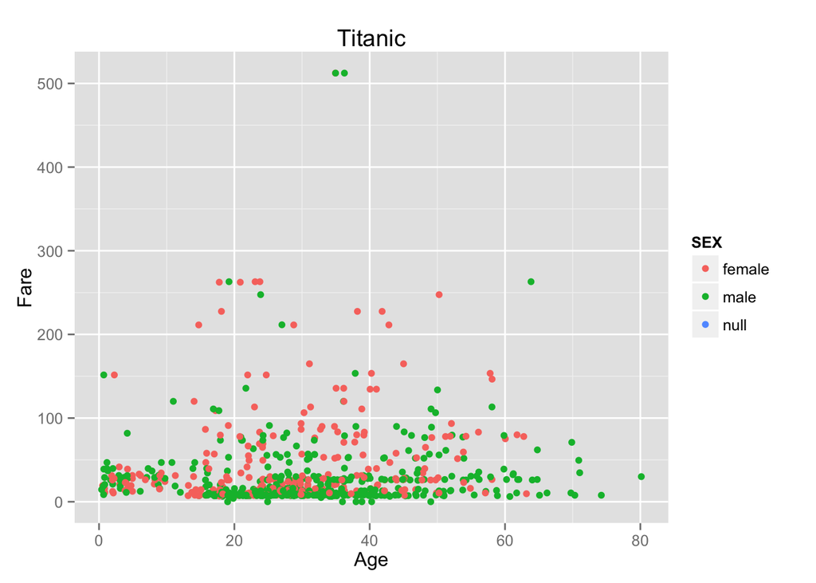

```r
source("../02 Visualizations/graph1.R", echo = TRUE)
```

#### Graph 2:

The graph below is a visualization of age vs fare paid, vs sex. Age is placed on the x-axis as a continuous variable, fare is on the y-axis, also as a continuous variable. Sex is distributed by color, with male being blue, and female being red. The query used was: “select * from titanic where sex is not null”, and ggplot was used to visualize the data. This graph is similar to graph 1, with the main difference being that the query to the data base included “where sex is not null”, which explains, why there is no null variable for sex in represented in this graph.

```
##
## > df <- data.frame(fromJSON(getURL(URLencode("129.152.144.84:5001/rest/native/?query=\"select * from titanic where sex is not null \""),
## +     httphe .... [TRUNCATED]
##
## > ggplot() + coord_cartesian() + scale_x_continuous() +
## +     scale_y_continuous() + labs(title = "Titanic") + labs(x = "Age",
## +     y = paste("Fare ..." ... [TRUNCATED]
```

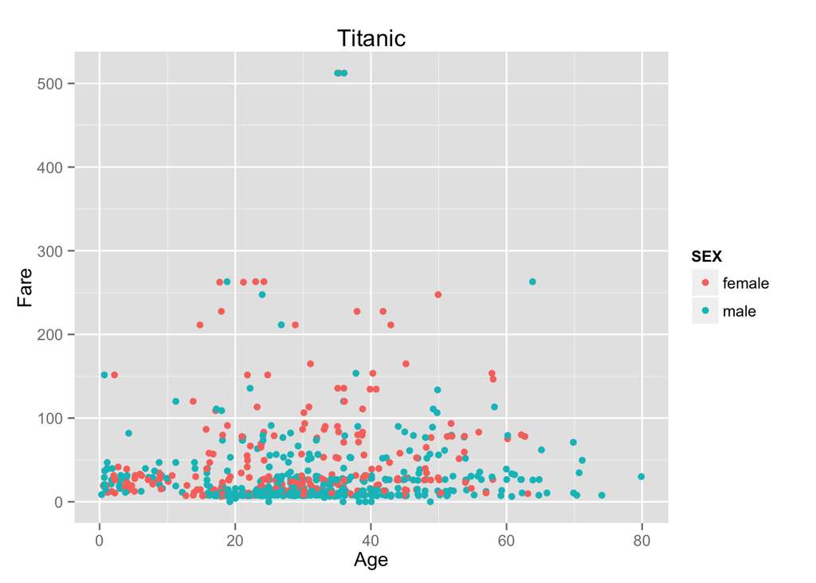

```r
source("../02 Visualizations/graph2.R", echo = TRUE)
```

#### Graph 3:

```
##
## > df <- data.frame(fromJSON(getURL(URLencode("129.152.144.84:5001/rest/native/?query=\"select * from titanic where sex is not null \""),
## +     httphe .... [TRUNCATED]
##
## > ggplot() + coord_cartesian() + scale_x_discrete() +
## +     scale_y_continuous() + labs(title = "Titanic") + labs(x = "Survived",
## +     y = paste("F ..." ... [TRUNCATED]
```

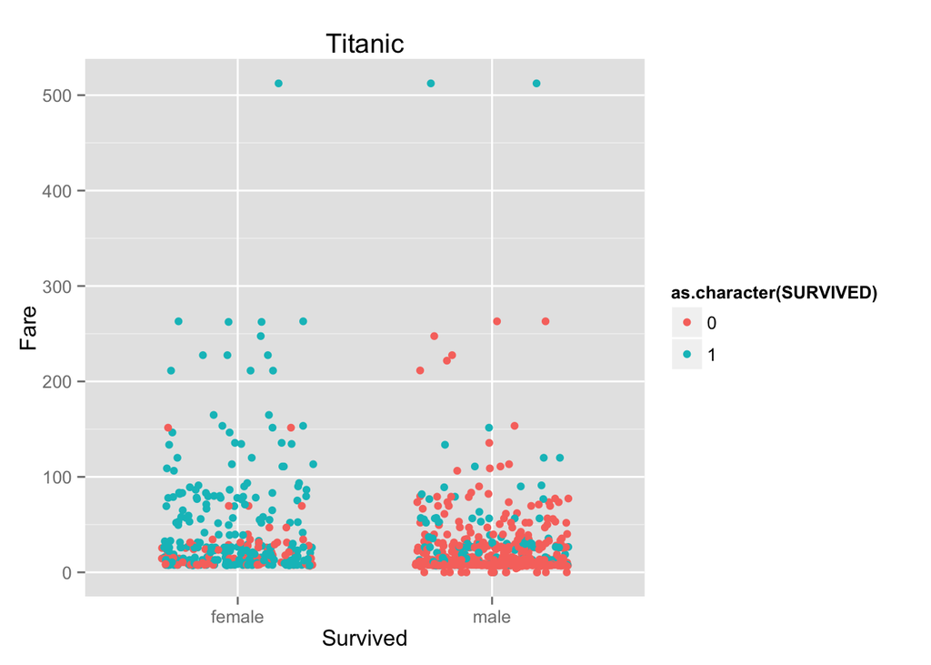

```r
source("../02 Visualizations/graph3.R", echo = TRUE)
```

#### Graph 4:

```
##
## > df <- data.frame(fromJSON(getURL(URLencode("129.152.144.84:5001/rest/native/?query=\"select * from titanic where sex is not null \""),
## +     httphe .... [TRUNCATED]
##
## > ggplot() + coord_cartesian() + scale_x_discrete() +
## +     scale_y_continuous() + facet_grid(PCLASS ~ SURVIVED, labeller = label_both) +
## +     labs .... [TRUNCATED]
```

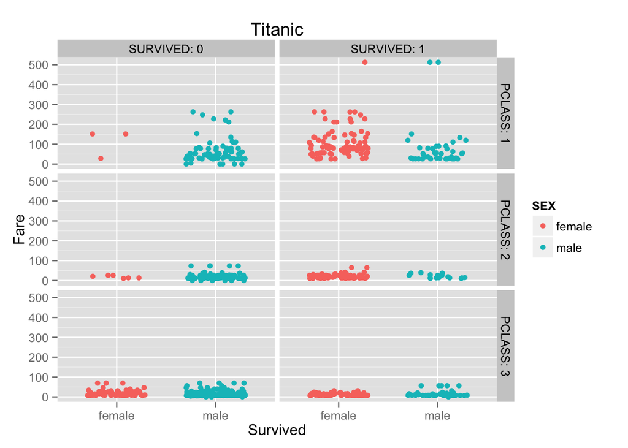

```r
source("../02 Visualizations/graph4.R", echo = TRUE)
```